# Método 0: Informação sobre Temperatura dos municípios (R)

Esse código faz o seguinte: extrai as informações do arquivo (.nc) para uma determinada região do mapa (o limite do município), depois ele converte essa informação para o formato de tabela.

Primeiro vamos importar os dados e visualizar graficamente a metodologia.

```r
#importar bibliotecas
library(sf) #permite trabalhar com arquivos .shp
library(tidyverse) #permite usar %>%
```

```r
#importar shapefile de municípios brasileiros
#site para fazer download do arquivo anterior:
#https://www.ibge.gov.br/geociencias/organizacao-do-territorio/estrutura-territorial/15774-malhas.html?=&t=downloads
mun = st_read('/home/felipe/Documents/bacen/variaveis_ambientais/br_municipios/BR_Municipios_2019.shp')

#extrair informações sobre o codigo dos mun do arquivo .shp
cod.mun = as.data.frame(mun)[,c(1,2,3)]
```

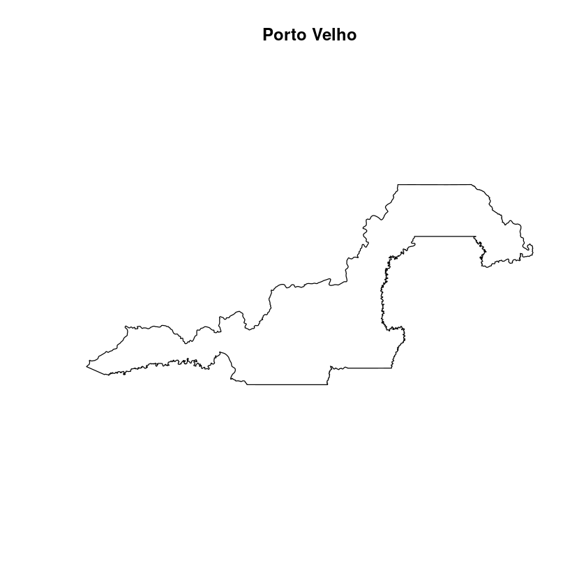

```r
#exemplo da geometria de um município
i = 17
mun_i = mun$geometry[mun$CD_MUN==cod.mun[i,'CD_MUN']]
plot(mun_i, main = cod.mun$NM_MUN[17])
```

```r
#importar arquivo .nc contendo informações sobre a temperatura do planeta (escala de (0.5° x 0.5°)
library(raster) #permite trabalhar com arquivos .nc
library(ncdf4)
db_temp = brick('/home/felipe/Documents/bacen/variaveis_ambientais/cru_tmp.nc') # os dados de temperatura mudam se eu utilizar o arquivo 3.26 ou 4.04
#restingir o período analisado
db_temp = subset(db_temp, which(getZ(db_temp) >= '1996-01-01' & (getZ(db_temp) <= '1996-01-31')))
#restringir a área analisada (apenas o Brasil)
db_temp = crop(db_temp, extent(db_temp, 150, 300, 150, 300),snap='near')
#Garantir que o sistema de coordenada dos dois arquivos são iguais
mun <- st_transform(mun, crs = st_crs(db_temp))
```

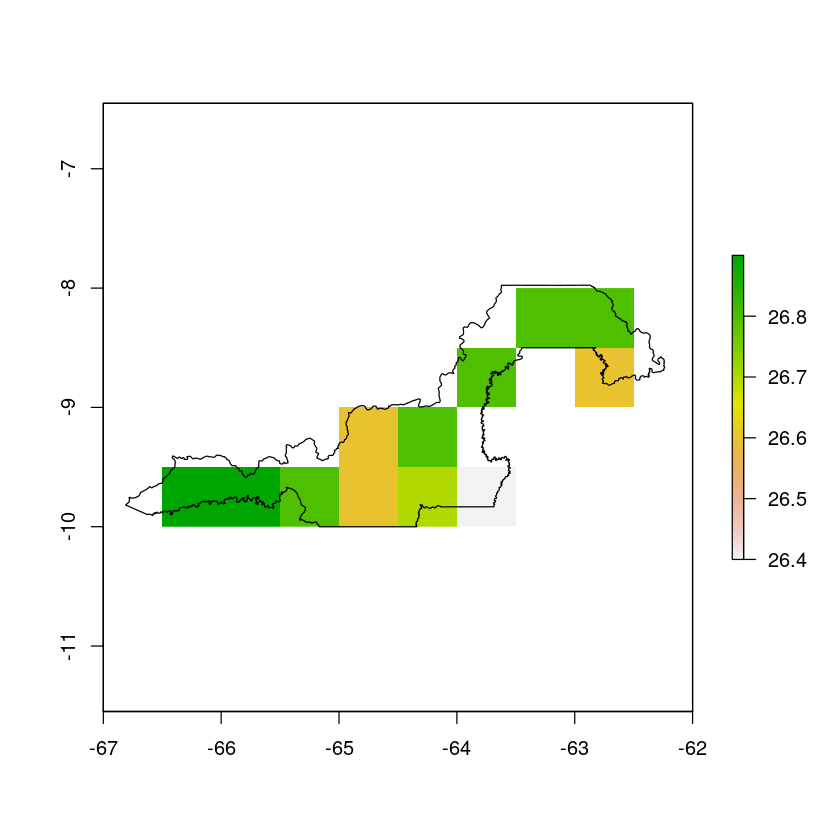

```r
#plotar exemplo de dados de temperatura para o município (17)
i=17
mun_i = mun$geometry[mun$CD_MUN==cod.mun[i,'CD_MUN']]
mun_i2 = as_Spatial(mun_i); #transformar classe (.sfc) para classe (sp) para ser entendido e usado junto com o arquivo nc
mun_i.nc = mask(db_temp,mun_i2,inverse=FALSE) %>% crop(mun_i2,snap = 'near')
plot(mun_i.nc)
plot(mun_i,add=TRUE)
```

Nós já temos as temperaturas que foram medidas para o município (i) agora é só criar um loop para coletar a temperatura de cada município brasileiro. Esse processo pode demorar um pouco, por isso eu realizei o loop apenas para 5 municípios. Lembre também que estou trabalhando apenas com o intervalo de tempo: '1996-01-01' a '1996-01-31'. Para aumentar essa janela é só alterar o código do bloco 4.

```r
# Importar bibliotecas para trabalhar com arquivos .nc
library(cruts)
library(rgdal)
library(raster)

df = data.frame()
for(i in 1:5){
  print(i);
  mun_i = mun$geometry[mun$CD_MUN==cod.mun[i,'CD_MUN']]; #geometria do mun i (classe: .sfc)
  mun_i = as_Spatial(mun_i); #transformar classe (.sfc) para classe (sp) para ser entendido e usado junto com o arquivo nc
  #mun_i.nc = fun1(mun_i); #coletar informações do arquivo .nc sobre o município i
  mun_i.nc = mask(db_temp,mun_i,inverse=FALSE) %>% crop(mun_i,snap = 'near') #inverse ok to mun 2
  if(all(is.na(getValues(mun_i.nc)))){print(paste('precisa inverter: ',cod.mun[i,'NM_MUN']));;mun_i.nc = mask(db_temp,mun_i,inverse=TRUE) %>% crop(mun_i,snap = 'near')}
  mun_i.df = rasterToPoints(mun_i.nc); #transformar .nc em array
  mun_i.df = as.data.frame(mun_i.df); #trasnformar para dataframe
  mun_i.df$grid =  c(1:nrow(mun_i.df)); #numerar grids que cobrem o município i
  mun_i.df$mun = cod.mun[i,'NM_MUN']; #adicionar informação ao df (nome do mun i)
  mun_i.df$cod.mun = cod.mun[i,'CD_MUN']; #adicionar informação ao df (código do mun i)
  mun_i.df$uf = cod.mun[i,'SIGLA_UF']; #adicionar informação ao df (sigla do estado do mun i)
  mun_i.df = gather(mun_i.df,'data','temp', 3:(length(mun_i.df)-4)) #transpose
  df = rbind(df,mun_i.df) #adicionar dados sobre o mun i ao df final
  }
```

[output not shown]

```
[1] 1
[1] 2
[1] "precisa inverter:  Ariquemes"
[1] 3
[1] "precisa inverter:  Cabixi"
[1] 4
[1] 5
```

```r
#visualizando o dataframe bruto
df
```

A data.frame: 11 × 8

| x <dbl> | y <dbl> | grid <int> | mun <chr> | cod.mun <chr> | uf <chr> | data <chr> | temp <dbl> |
| --- | --- | --- | --- | --- | --- | --- | --- |
| -62.25 | -12.25 | 1 | Alta Floresta D'Oeste | 1100015 | RO | X1996.01.16 | 26.1 |
| -62.25 | -12.75 | 2 | Alta Floresta D'Oeste | 1100015 | RO | X1996.01.16 | 26.5 |
| -63.25 | -9.75 | 1 | Ariquemes | 1100023 | RO | X1996.01.16 | 26.3 |
| -62.75 | -9.75 | 2 | Ariquemes | 1100023 | RO | X1996.01.16 | 26.1 |
| -63.25 | -10.25 | 3 | Ariquemes | 1100023 | RO | X1996.01.16 | 26.2 |
| -62.75 | -10.25 | 4 | Ariquemes | 1100023 | RO | X1996.01.16 | 26.0 |
| -60.75 | -13.75 | 1 | Cabixi | 1100031 | RO | X1996.01.16 | 26.1 |
| -61.25 | -11.25 | 1 | Cacoal | 1100049 | RO | X1996.01.16 | 25.8 |
| -61.75 | -13.25 | 1 | Cerejeiras | 1100056 | RO | X1996.01.16 | 26.4 |
| -61.25 | -13.25 | 2 | Cerejeiras | 1100056 | RO | X1996.01.16 | 26.2 |
| -60.75 | -13.25 | 3 | Cerejeiras | 1100056 | RO | X1996.01.16 | 25.8 |

```r
#resumir informação do df
df1 = df[4:8]
df1$data = gsub("X", "", df1$data)
df1$data = gsub("\\.", "-", df1$data)

df_min = df1 %>% group_by(mun,cod.mun,uf,data) %>% summarise(min=min(temp)) #agregar dados e criar coluna de temp min
df_max = df1 %>% group_by(mun,cod.mun,uf,data) %>% summarise(max=max(temp)) #agregar dados e criar coluna de temp max
df_mean = df1 %>% group_by(mun,cod.mun,uf,data) %>% summarise(mean=mean(temp)) #agregar dados e criar coluna de temp max

df2 = merge(df_min,df_max,by.x=c('mun','cod.mun','data','uf'),by.y=c('mun','cod.mun','data','uf'))
df2 = merge(df_mean,df2,by.x=c('mun','cod.mun','data','uf'),by.y=c('mun','cod.mun','data','uf'))

head(df2)
```

A data.frame: 5 × 7

|  | mun <chr> | cod.mun <chr> | data <chr> | uf <chr> | mean <dbl> | min <dbl> | max <dbl> |
| --- | --- | --- | --- | --- | --- | --- | --- |
| 1 | Alta Floresta D'Oeste | 1100015 | 1996-01-16 | RO | 26.30000 | 26.1 | 26.5 |
| 2 | Ariquemes | 1100023 | 1996-01-16 | RO | 26.15000 | 26.0 | 26.3 |
| 3 | Cabixi | 1100031 | 1996-01-16 | RO | 26.10000 | 26.1 | 26.1 |
| 4 | Cacoal | 1100049 | 1996-01-16 | RO | 25.80000 | 25.8 | 25.8 |
| 5 | Cerejeiras | 1100056 | 1996-01-16 | RO | 26.13333 | 25.8 | 26.4 |

### Resumo dobre os dados do (CRU)

O centro de pesquisa climática (Climatic Research Unit - CRU) da universidade inglesa East Anglia cria e disponibiliza dados climáticos (temperatura, precipitação, pressão, etc). Esses dados podem ter frequência mensal, escala de (0.5° x 0.5°) a (10° x 10°) e cobrir todo o globo.

Esse centro coleta dados de estações climatológicas ao redor do mundo, verifica confiabilidade dos mesmos e, para os locais sem dados, eles usam técnicas de interpolação espacial. A metodologia está descrita no artigo:

Harris, I., Jones, P.D., Osborn, T.J. and Lister, D.H. (2014), Updated high-resolution grids of monthly climatic observations – the CRU TS3.10 Dataset. Int. J. Climatol., 34: 623–642. doi:10.1002/joc.3711

Depois de prontos os dados são disponibilizados no Centre for Environmental Data Analysis (CEDA), que é uma organização inglesa para criar e divulgar dados climáticos de forma colaborativa. Os dados são disponibilizados em um formato que permite agrupar multiplas dimensões e variáveis : no formato '.nc' --- acrônimo para: NetCDF (Network Common Data Form) ---